# Group3_Project

Bundi Kirimi

2/7/2022

##**1. Defining the Question**##

##**a) Specifying the Data Analytic Question**##

find out the factors that influence pricing of apartments

##**b) Defining the Metric for Success** ##

```
This project will be successful when our model reaches an Accuracy of between 75-95%
```

##**c) Understanding the context**##

The dataset was acquired fro the Deagu District in Korea.It outlines the various factors that influence the price of an Apartment.

d)Recording the Experimental Design

```
Loading Libraries


Reading the dataset

Data Cleaning

Exploratory Data Anlysis

Feature Engineering

Model Training

Model Evaluation

Conclusion

Recommendations
```

##**e) Data Relevance**##

We are using the Apartments data consisting of 30 variables: ‘SalePrice’, ‘Age’, ‘Size.sqf.’, ‘Floor’, ‘Management Type’ etc. The main variable we are interested in is the SalePrice

##**2. Loading the libraries**##

#Loading the libraries

```r
#specify the path where the file is located
library("data.table")
library(tidyverse)
library(magrittr)
```

```r
library(warn = -1)
library("ggbiplot")
library(ggplot2)
library(lattice)
library(corrplot)
library(DataExplorer)
library(pastecs)
library(psych)
library(factoextra)
library(caret)
```

##**3.)Loading the data**##

```r
#Loading the data
path <-"C:/Users/Jerome/Downloads/Daegu_Real_Estate_data.csv"

df<-read.csv(path, sep = ",")

head(df)
```

```
##   SalePrice YearBuilt YrSold MonthSold Size.sqf. Floor HallwayType
## 1    141592      2006   2007         8       814     3    terraced
## 2     51327      1985   2007         8       587     8    corridor
## 3     48672      1985   2007         8       587     6    corridor
## 4    380530      2006   2007         8      2056     8    terraced
## 5    221238      1993   2007         8      1761     3       mixed
## 6     35840      1992   2007         8       355     5    corridor
##          HeatingType       AptManageType N_Parkinglot.Ground.
## 1 individual_heating management_in_trust                  111
## 2 individual_heating     self_management                   80
## 3 individual_heating     self_management                   80
## 4 individual_heating management_in_trust                  249
## 5 individual_heating management_in_trust                  523
## 6 individual_heating management_in_trust                  200
##   N_Parkinglot.Basement. TimeToBusStop TimeToSubway N_APT N_manager N_elevators
```

[output cut: 48 more lines]

#Previewing the summary of the dataset

```r
summary(df)
```

```
##    SalePrice        YearBuilt        YrSold       MonthSold
##  Min.   : 32743   Min.   :1978   Min.   :2007   Min.   : 1.00
##  1st Qu.:144247   1st Qu.:1993   1st Qu.:2010   1st Qu.: 3.00
##  Median :207964   Median :2006   Median :2013   Median : 6.00
##  Mean   :221218   Mean   :2003   Mean   :2013   Mean   : 6.16
##  3rd Qu.:291150   3rd Qu.:2008   3rd Qu.:2015   3rd Qu.: 9.00
##  Max.   :585840   Max.   :2015   Max.   :2017   Max.   :12.00
##    Size.sqf.          Floor       HallwayType        HeatingType
##  Min.   : 135.0   Min.   : 1.00   Length:5891        Length:5891
##  1st Qu.: 644.0   1st Qu.: 6.00   Class :character   Class :character
##  Median : 910.0   Median :11.00   Mode  :character   Mode  :character
##  Mean   : 955.6   Mean   :12.03
##  3rd Qu.:1149.0   3rd Qu.:17.00
##  Max.   :2337.0   Max.   :43.00
##  AptManageType      N_Parkinglot.Ground. N_Parkinglot.Basement.
##  Length:5891        Min.   :  0.0        Min.   :   0.0
##  Class :character   1st Qu.: 11.0        1st Qu.: 184.0
##  Mode  :character   Median :100.0        Median : 536.0
##                     Mean   :195.9        Mean   : 570.8
##                     3rd Qu.:249.0        3rd Qu.: 798.0
##                     Max.   :713.0        Max.   :1321.0
##  TimeToBusStop      TimeToSubway           N_APT          N_manager
##  Length:5891        Length:5891        Min.   : 1.000   Min.   : 1.00
##  Class :character   Class :character   1st Qu.: 3.000   1st Qu.: 5.00
##  Mode  :character   Mode  :character   Median : 7.000   Median : 6.00
##                                        Mean   : 5.614   Mean   : 6.31
##                                        3rd Qu.: 8.000   3rd Qu.: 8.00
##                                        Max.   :13.000   Max.   :14.00
##   N_elevators    SubwayStation      N_FacilitiesNearBy.PublicOffice.
##  Min.   : 0.00   Length:5891        Min.   :0.000
##  1st Qu.: 5.00   Class :character   1st Qu.:3.000
##  Median :11.00   Mode  :character   Median :5.000
##  Mean   :11.15                      Mean   :4.142
##  3rd Qu.:16.00                      3rd Qu.:5.000
##  Max.   :27.00                      Max.   :7.000
##  N_FacilitiesNearBy.Hospital. N_FacilitiesNearBy.Dpartmentstore.
##  Min.   :0.000                Min.   :0.0000
##  1st Qu.:1.000                1st Qu.:0.0000
##  Median :1.000                Median :1.0000
##  Mean   :1.296                Mean   :0.8963
```

[output cut: 15 more lines]

```
##  Max.   :6.000              Max.   :4.000          Max.   :5.000
##  N_SchoolNearBy.University. N_FacilitiesInApt N_FacilitiesNearBy.Total.
##  Min.   :0.000              Min.   : 1.00     Min.   : 0.000
##  1st Qu.:2.000              1st Qu.: 4.00     1st Qu.: 8.000
##  Median :2.000              Median : 5.00     Median : 9.000
##  Mean   :2.765              Mean   : 5.81     Mean   : 9.871
##  3rd Qu.:4.000              3rd Qu.: 7.00     3rd Qu.:13.000
##  Max.   :5.000              Max.   :10.00     Max.   :16.000
##  N_SchoolNearBy.Total.
##  Min.   : 0.00
##  1st Qu.: 7.00
##  Median :10.00
##  Mean   :10.86
##  3rd Qu.:15.00
##  Max.   :17.00
```

The mean of Sale Price of an apartment in Deagu is 221218 whereas the median is 207964. This suggests that the data is right_skewed/Positvely_skewed.

##**4)Checking the data**##

```r
#Length
length(df)
```

```
## [1] 30
```

The dataframe has 30 columns

```r
#Dimensions
dim(df)
```

```
## [1] 5891   30
```

The dataframe has 5891 row entries and 30 columns

Column Names

```r
colnames(df)
```

```
##  [1] "SalePrice"                          "YearBuilt"
##  [3] "YrSold"                             "MonthSold"
##  [5] "Size.sqf."                          "Floor"
##  [7] "HallwayType"                        "HeatingType"
##  [9] "AptManageType"                      "N_Parkinglot.Ground."
## [11] "N_Parkinglot.Basement."             "TimeToBusStop"
## [13] "TimeToSubway"                       "N_APT"
## [15] "N_manager"                          "N_elevators"
## [17] "SubwayStation"                      "N_FacilitiesNearBy.PublicOffice."
## [19] "N_FacilitiesNearBy.Hospital."       "N_FacilitiesNearBy.Dpartmentstore."
## [21] "N_FacilitiesNearBy.Mall."           "N_FacilitiesNearBy.ETC."
## [23] "N_FacilitiesNearBy"                 "N_SchoolNearBy.Elementary."
## [25] "N_SchoolNearBy.Middle."             "N_SchoolNearBy.High."
## [27] "N_SchoolNearBy.University."         "N_FacilitiesInApt"
## [29] "N_FacilitiesNearBy.Total."          "N_SchoolNearBy.Total."
```

Column data types

```r
sapply(df, class)
```

```
##                          SalePrice                          YearBuilt
##                          "integer"                          "integer"
##                             YrSold                          MonthSold
##                          "integer"                          "integer"
##                          Size.sqf.                              Floor
##                          "integer"                          "integer"
##                        HallwayType                        HeatingType
##                        "character"                        "character"
##                      AptManageType               N_Parkinglot.Ground.
##                        "character"                          "numeric"
##             N_Parkinglot.Basement.                      TimeToBusStop
##                          "numeric"                        "character"
##                       TimeToSubway                              N_APT
##                        "character"                          "numeric"
##                          N_manager                        N_elevators
##                          "numeric"                          "numeric"
##                      SubwayStation   N_FacilitiesNearBy.PublicOffice.
##                        "character"                          "numeric"
##       N_FacilitiesNearBy.Hospital. N_FacilitiesNearBy.Dpartmentstore.
##                          "integer"                          "numeric"
##           N_FacilitiesNearBy.Mall.            N_FacilitiesNearBy.ETC.
##                          "numeric"                          "numeric"
##                 N_FacilitiesNearBy         N_SchoolNearBy.Elementary.
##                          "numeric"                          "numeric"
##             N_SchoolNearBy.Middle.               N_SchoolNearBy.High.
##                          "numeric"                          "numeric"
##         N_SchoolNearBy.University.                  N_FacilitiesInApt
##                          "numeric"                          "integer"
##          N_FacilitiesNearBy.Total.              N_SchoolNearBy.Total.
##                          "numeric"                          "numeric"
```

Our data has numerical,categorical and character variables

##**5)Data Cleaning**##

```r
sum(is.na(df))
```

```
## [1] 0
```

There are no Null Values

Checking for Dupicates

```r
#Duplicates
duplicated_rows <- df[duplicated(df),]

dim(duplicated_rows)
```

```
## [1] 316  30
```

We found 316 rows weere duplicated

Removing duplicates

```r
df1 <- df[-which(duplicated(df)), ]
dim(df1)
```

```
## [1] 5575   30
```

Our data has 5575 rows and 30 columns after removing the duplicates

Data Types

```r
sapply(df1, class)
```

```
##                          SalePrice                          YearBuilt
##                          "integer"                          "integer"
##                             YrSold                          MonthSold
##                          "integer"                          "integer"
##                          Size.sqf.                              Floor
##                          "integer"                          "integer"
##                        HallwayType                        HeatingType
##                        "character"                        "character"
##                      AptManageType               N_Parkinglot.Ground.
##                        "character"                          "numeric"
##             N_Parkinglot.Basement.                      TimeToBusStop
##                          "numeric"                        "character"
##                       TimeToSubway                              N_APT
##                        "character"                          "numeric"
##                          N_manager                        N_elevators
##                          "numeric"                          "numeric"
##                      SubwayStation   N_FacilitiesNearBy.PublicOffice.
##                        "character"                          "numeric"
##       N_FacilitiesNearBy.Hospital. N_FacilitiesNearBy.Dpartmentstore.
##                          "integer"                          "numeric"
##           N_FacilitiesNearBy.Mall.            N_FacilitiesNearBy.ETC.
##                          "numeric"                          "numeric"
##                 N_FacilitiesNearBy         N_SchoolNearBy.Elementary.
##                          "numeric"                          "numeric"
##             N_SchoolNearBy.Middle.               N_SchoolNearBy.High.
##                          "numeric"                          "numeric"
##         N_SchoolNearBy.University.                  N_FacilitiesInApt
##                          "numeric"                          "integer"
##          N_FacilitiesNearBy.Total.              N_SchoolNearBy.Total.
##                          "numeric"                          "numeric"
```

##**6)Exploratory Data Analysis**##

#*Univariate Analysis*#

Checking the categorical variables

```r
#Visualizing the Hallway types
unique(df1$HallwayType)
```

```
## [1] "terraced" "corridor" "mixed"
```

```r
factor(unique(df1$HallwayType))
```

```
## [1] terraced corridor mixed
## Levels: corridor mixed terraced
```

```r
#Visualizing the Heating type
unique(df1$HeatingType)
```

```
## [1] "individual_heating" "central_heating"
```

```r
factor(unique(df1$HeatingType))
```

```
## [1] individual_heating central_heating
## Levels: central_heating individual_heating
```

```r
#Visualizing the Apartment Type
unique(df1$AptManageType)
```

```
## [1] "management_in_trust" "self_management"
```

```r
factor(unique(df1$AptManageType))
```

```
## [1] management_in_trust self_management
## Levels: management_in_trust self_management
```

Hallway Types

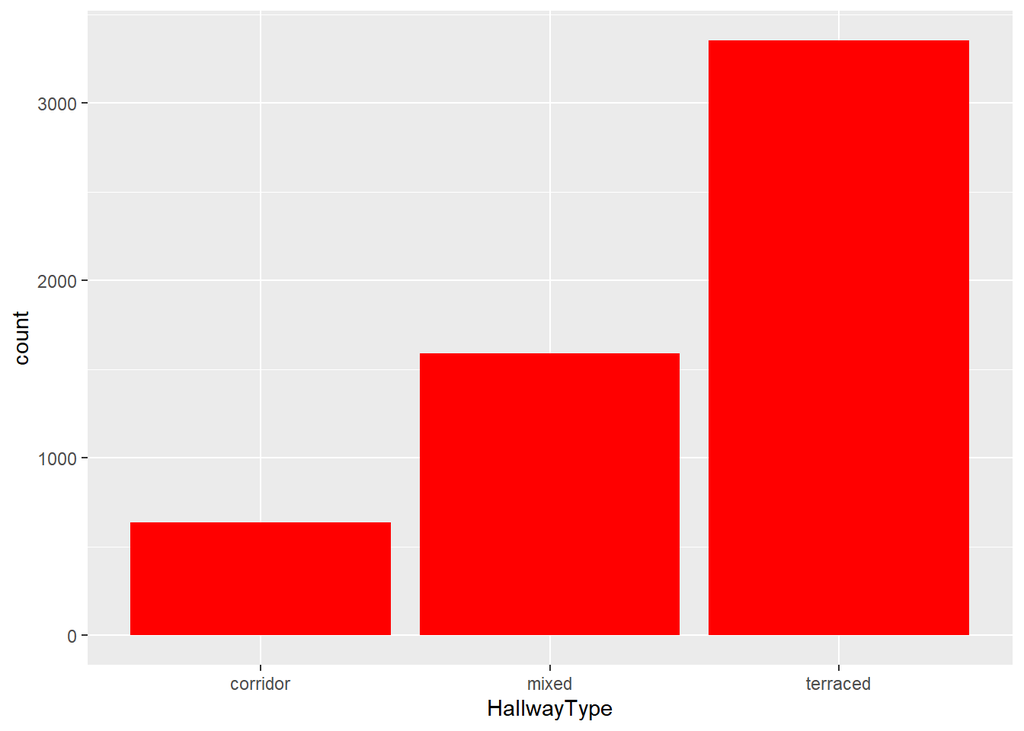

```r
#Visualizing the Hallway types

library(ggplot2)
ggplot(df1, aes(HallwayType)) +
   geom_bar(fill = "red")
```

We can see most apartments have terraced Hallway types.

Apartment Management Type

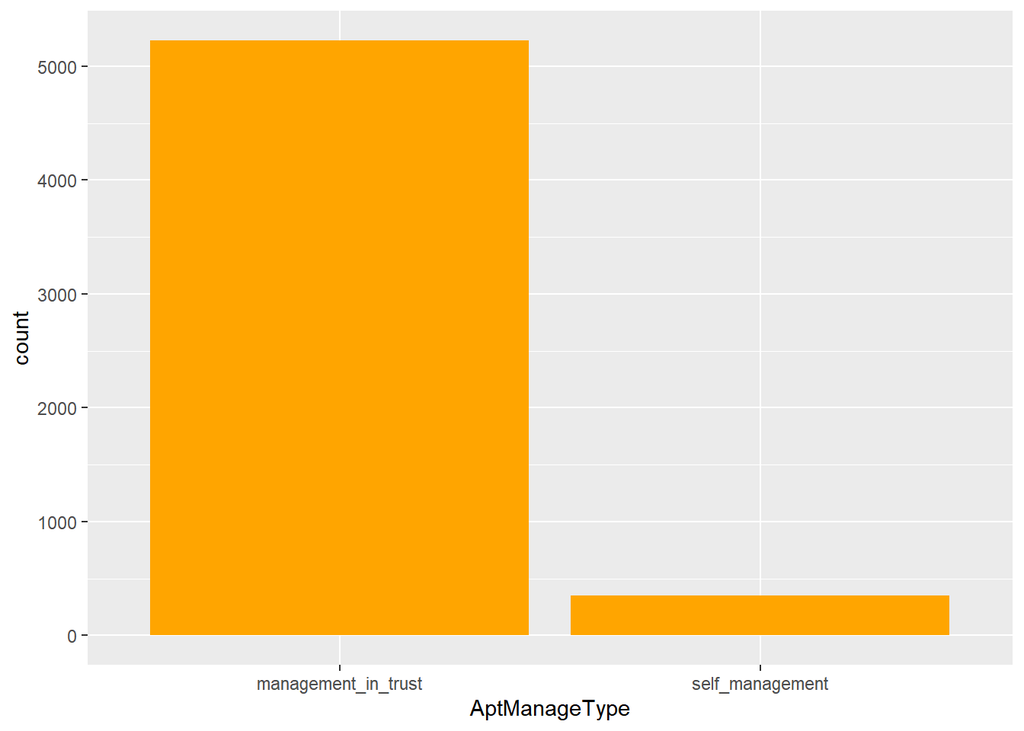

```r
#Visualizing the Apartment Management types

library(ggplot2)
ggplot(df1, aes(AptManageType)) +
   geom_bar(fill = "Orange")
```

Most Apartments had Management System by trust while very few had self management

Heating Systems

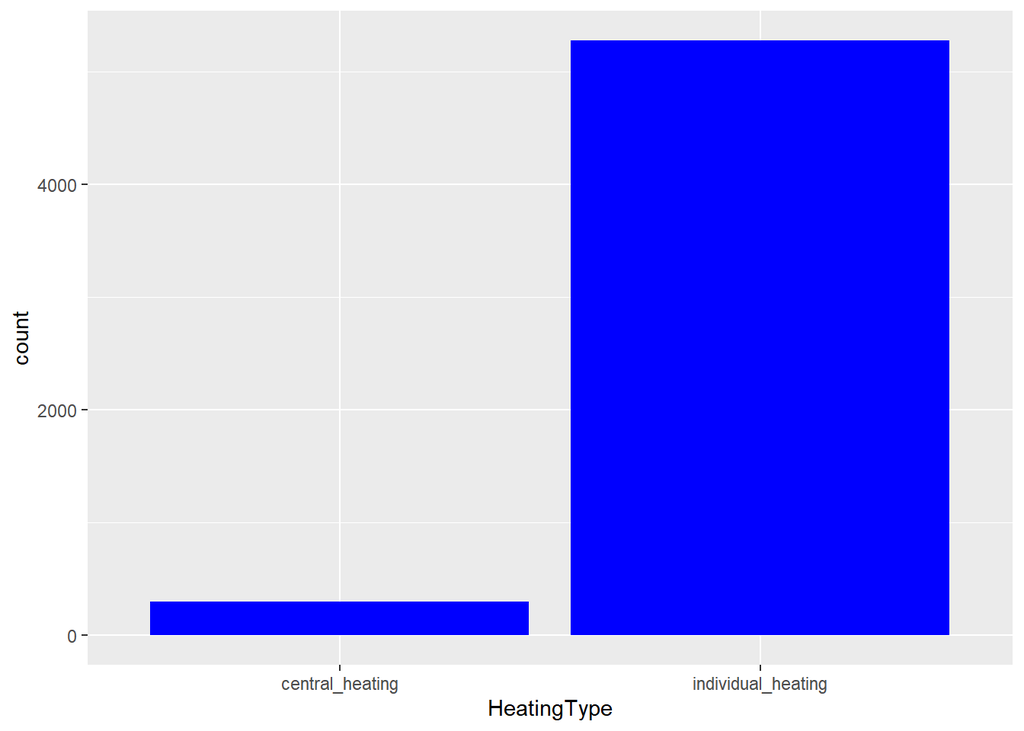

```r
#Visualizing the heating systems

library(ggplot2)
ggplot(df1, aes(HeatingType)) +
   geom_bar(fill = "Blue")
```

Most Apartments had Individual Heating System while very few had central heating sytsems

Sale Price

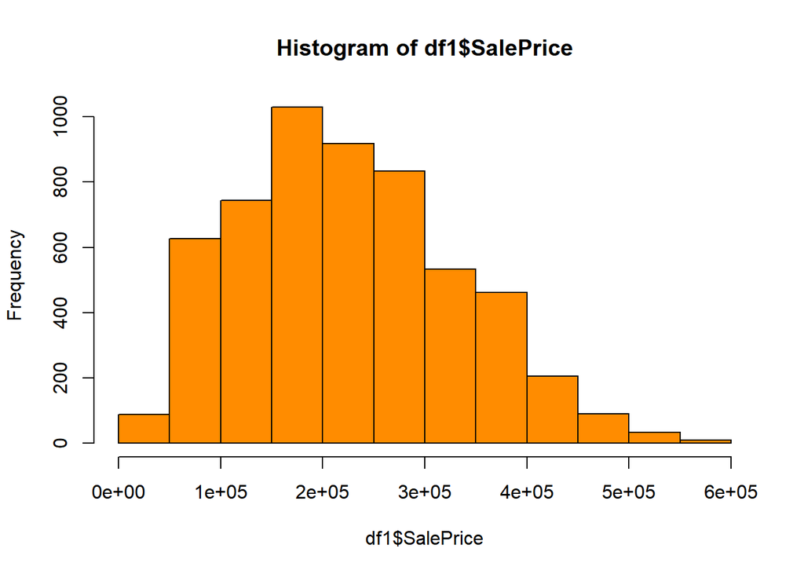

```r
#
#each of the values printed below appear thrice in the dataset
#distribution
hist(df1$SalePrice , col=c("darkorange"))
```

Size in Squarefoot of The Apartments

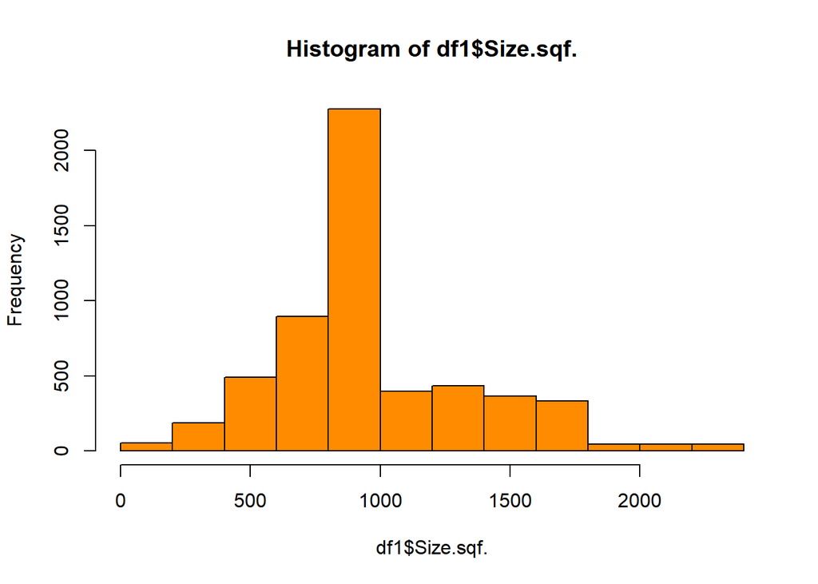

```r
#Histogram of size in squarefoot
hist(df1$Size.sqf. , col=c("darkorange"))
```

Floor Number

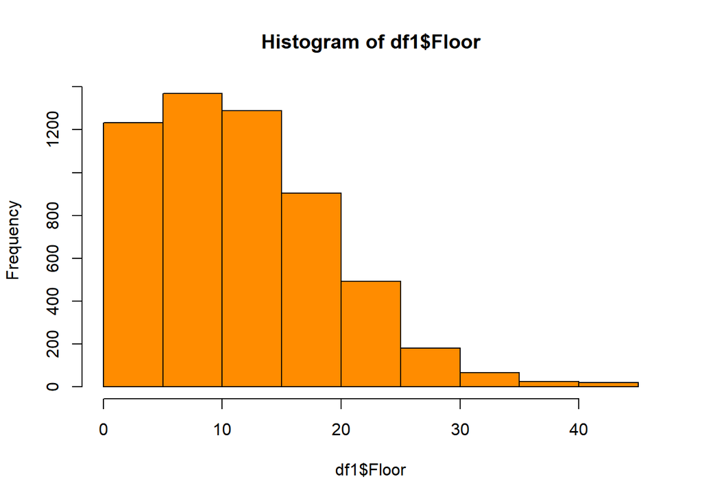

```r
#Histogram of floor column
#distribution
hist(df1$Floor , col=c("darkorange"))
```

The data is skewed to the right. Thus suggests that there is very minimal buildings with so many floors compared to the ones with few floors

Creating New column Age that has the difference in years of since the house was built and when it was sold

```r
df1$Age <- df1$YrSold - df1$YearBuilt
```

Adding the created Age column to our dataframe

```r
data <- df1[ c(1,5,6,7,8,9,10,11,14,15,16,18,19,20,21,22,23,28,29,30,31) ]

head(data)
```

```
##   SalePrice Size.sqf. Floor HallwayType        HeatingType       AptManageType
## 1    141592       814     3    terraced individual_heating management_in_trust
## 2     51327       587     8    corridor individual_heating     self_management
## 3     48672       587     6    corridor individual_heating     self_management
## 4    380530      2056     8    terraced individual_heating management_in_trust
## 5    221238      1761     3       mixed individual_heating management_in_trust
## 6     35840       355     5    corridor individual_heating management_in_trust
##   N_Parkinglot.Ground. N_Parkinglot.Basement. N_APT N_manager N_elevators
## 1                  111                    184     3         3           0
## 2                   80                     76     1         2           2
## 3                   80                     76     1         2           2
## 4                  249                    536     6         5          11
## 5                  523                    536     8         8          20
## 6                  200                      0     3         5          10
##   N_FacilitiesNearBy.PublicOffice. N_FacilitiesNearBy.Hospital.
```

[output cut: 27 more lines]

Age Difference i Years

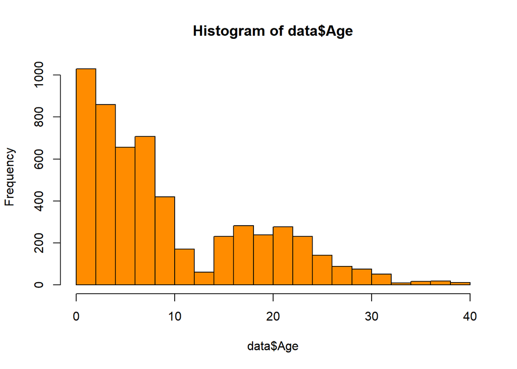

```r
#Distrbution of difference in years of the year built and year sold

#distribution
hist(data$Age , col=c("darkorange"))
```

The data is skewed to the right. Most houses in the dataset were newly built

Summary

```r
summary(data)
```

```
##    SalePrice        Size.sqf.          Floor       HallwayType
##  Min.   : 32743   Min.   : 135.0   Min.   : 1.00   Length:5575
##  1st Qu.:147761   1st Qu.: 644.0   1st Qu.: 6.00   Class :character
##  Median :212389   Median : 910.0   Median :11.00   Mode  :character
##  Mean   :225612   Mean   : 969.8   Mean   :12.14
##  3rd Qu.:295575   3rd Qu.:1160.0   3rd Qu.:17.00
##  Max.   :585840   Max.   :2337.0   Max.   :43.00
##  HeatingType        AptManageType      N_Parkinglot.Ground.
##  Length:5575        Length:5575        Min.   :  0.0
##  Class :character   Class :character   1st Qu.: 25.0
##  Mode  :character   Mode  :character   Median :111.0
##                                        Mean   :203.3
##                                        3rd Qu.:249.0
##                                        Max.   :713.0
##  N_Parkinglot.Basement.     N_APT          N_manager       N_elevators
##  Min.   :   0.0         Min.   : 1.000   Min.   : 1.000   Min.   : 0.00
##  1st Qu.: 184.0         1st Qu.: 3.000   1st Qu.: 5.000   1st Qu.: 5.00
##  Median : 536.0         Median : 7.000   Median : 6.000   Median :11.00
##  Mean   : 557.4         Mean   : 5.553   Mean   : 6.343   Mean   :11.28
##  3rd Qu.: 798.0         3rd Qu.: 8.000   3rd Qu.: 8.000   3rd Qu.:16.00
##  Max.   :1321.0         Max.   :13.000   Max.   :14.000   Max.   :27.00
##  N_FacilitiesNearBy.PublicOffice. N_FacilitiesNearBy.Hospital.
##  Min.   :0.000                    Min.   :0.000
##  1st Qu.:3.000                    1st Qu.:1.000
##  Median :5.000                    Median :1.000
##  Mean   :4.114                    Mean   :1.292
##  3rd Qu.:5.000                    3rd Qu.:2.000
##  Max.   :7.000                    Max.   :2.000
##  N_FacilitiesNearBy.Dpartmentstore. N_FacilitiesNearBy.Mall.
##  Min.   :0.0000                     Min.   :0.0000
##  1st Qu.:0.0000                     1st Qu.:1.0000
##  Median :1.0000                     Median :1.0000
##  Mean   :0.9076                     Mean   :0.9387
##  3rd Qu.:2.0000                     3rd Qu.:1.0000
##  Max.   :2.0000                     Max.   :2.0000
##  N_FacilitiesNearBy.ETC. N_FacilitiesNearBy N_FacilitiesInApt
##  Min.   :0.000           Min.   :0.0000     Min.   : 1.000
##  1st Qu.:0.000           1st Qu.:0.0000     1st Qu.: 4.000
##  Median :1.000           Median :1.0000     Median : 5.000
##  Mean   :1.952           Mean   :0.6531     Mean   : 5.761
##  3rd Qu.:5.000           3rd Qu.:1.0000     3rd Qu.: 7.000
##  Max.   :5.000           Max.   :2.0000     Max.   :10.000
##  N_FacilitiesNearBy.Total. N_SchoolNearBy.Total.      Age
##  Min.   : 0.000            Min.   : 0.00         Min.   : 0.00
##  1st Qu.: 8.000            1st Qu.: 7.00         1st Qu.: 3.00
##  Median : 9.000            Median :10.00         Median : 7.00
##  Mean   : 9.857            Mean   :10.82         Mean   :10.08
##  3rd Qu.:13.000            3rd Qu.:15.00         3rd Qu.:17.00
##  Max.   :16.000            Max.   :17.00         Max.   :39.00
```

##**Bivariate Analysis**##

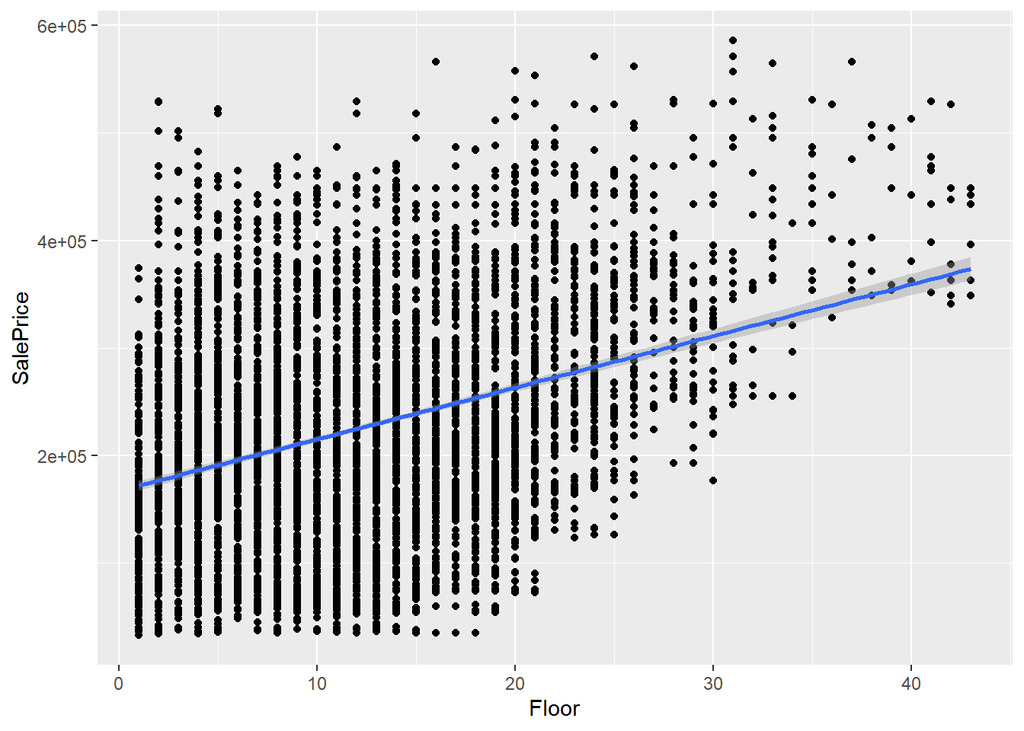

```r
#Sale Price Vs Size in Square foot of the house
ggplot(data, aes(x = Floor, y = SalePrice)) +
  geom_point() +
  stat_smooth(method = 'lm')
```

It is likely the higher the Apartment in terms of floor the more price of the Apartment

Apartment Management Type Vs The Sale Price

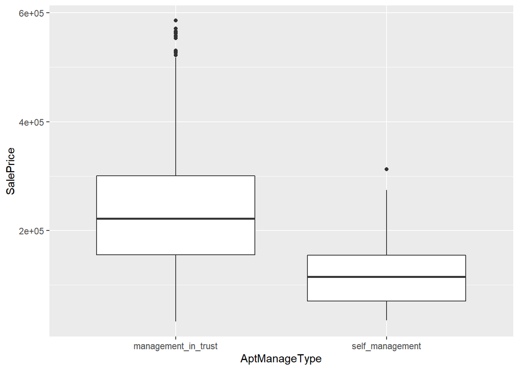

```r
ggplot(data, aes(x = AptManageType, y = SalePrice)) +
  geom_boxplot()
```

The Apartments managed by Trust are more expensive to Apartments managed by Individuals.

Plot of Apartment Age vs Price

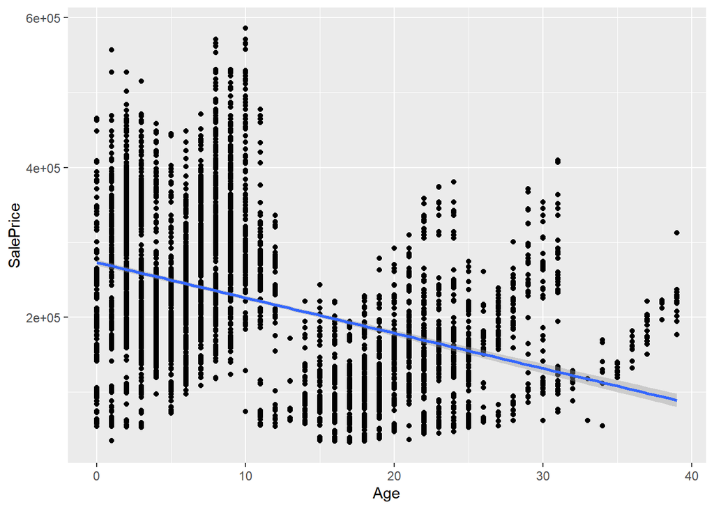

```r
ggplot(data, aes(x = Age, y = SalePrice)) +
  geom_point() +
  stat_smooth(method = 'lm')
```

As an Apartment Ages,the price Reduces

Plotting Size in Squarefoot of the Apartment vs The Sale Price

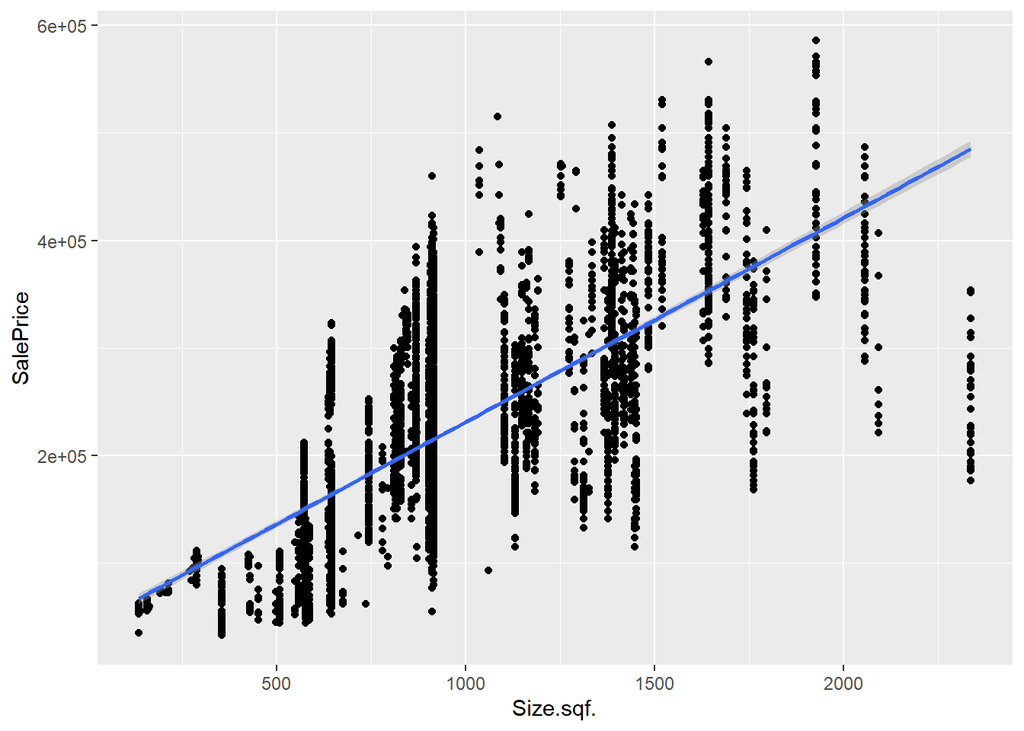

```r
    #create scatterplot

ggplot(data, aes(x = Size.sqf., y = SalePrice)) +
  geom_point() +
  stat_smooth(method = 'lm')
```

The Price of an Apartment increases with increase in Size of the Apartment

Plotting the Sale Price vs The number of Schools Nearby

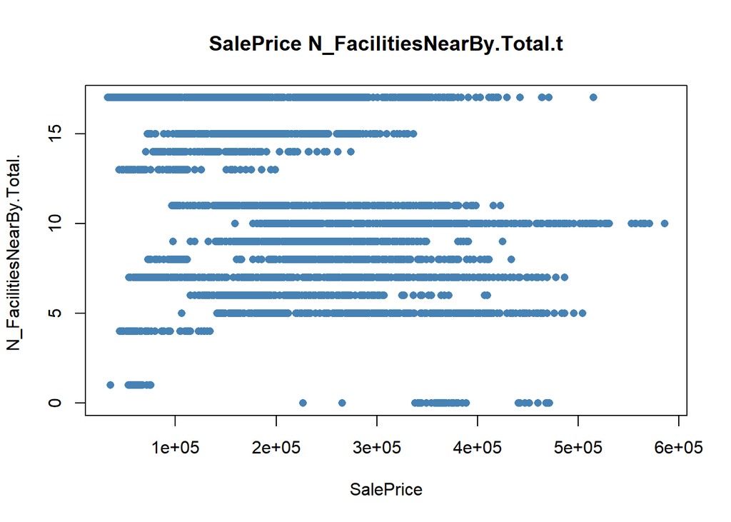

```r
#create scatterplot of e
plot(data$SalePrice, data$N_SchoolNearBy.Total.
, pch=16, col='steelblue',
     main='SalePrice N_FacilitiesNearBy.Total.t',
     xlab='SalePrice', ylab='N_FacilitiesNearBy.Total. ')
```

There is no direct relationship between the two variables

##**Feature engineering*##

```r
#select list of categorical variables,df1
df2 <- data[,c(4,5,6)]#categorical
#make a subset of non-categorical variables,df2
df3 <-data[,c(1,2,3,7,8,9,10,11,15,18,19,20,21)]
```

```r
head(df3)
```

```
##   SalePrice Size.sqf. Floor N_Parkinglot.Ground. N_Parkinglot.Basement. N_APT
## 1    141592       814     3                  111                    184     3
## 2     51327       587     8                   80                     76     1
## 3     48672       587     6                   80                     76     1
## 4    380530      2056     8                  249                    536     6
## 5    221238      1761     3                  523                    536     8
## 6     35840       355     5                  200                      0     3
##   N_manager N_elevators N_FacilitiesNearBy.Mall. N_FacilitiesInApt
## 1         3           0                        1                 5
## 2         2           2                        1                 3
## 3         2           2                        1                 3
## 4         5          11                        1                 5
## 5         8          20                        1                 4
## 6         5          10                        1                 3
##   N_FacilitiesNearBy.Total. N_SchoolNearBy.Total. Age
## 1                         6                     9   1
## 2                        12                     4  22
## 3                        12                     4  22
## 4                         3                     7   1
## 5                        14                    17  14
## 6                        16                    17  15
```

Dummy Encoding Categorical Variables

```r
dmy <- dummyVars(" ~ .", data = df2, fullRank = T)
df4 <- data.frame(predict(dmy, newdata = df2))

head(df4)
```

```
##   HallwayTypemixed HallwayTypeterraced HeatingTypeindividual_heating
## 1                0                   1                             1
## 2                0                   0                             1
## 3                0                   0                             1
## 4                0                   1                             1
## 5                1                   0                             1
## 6                0                   0                             1
##   AptManageTypeself_management
## 1                            0
## 2                            1
## 3                            1
## 4                            0
## 5                            0
## 6                            0
```

Joining the Categorical columns and numerical columns

```r
db <- cbind(df4,df3)
```

```r
head(db)
```

```
##   HallwayTypemixed HallwayTypeterraced HeatingTypeindividual_heating
## 1                0                   1                             1
## 2                0                   0                             1
## 3                0                   0                             1
## 4                0                   1                             1
## 5                1                   0                             1
## 6                0                   0                             1
##   AptManageTypeself_management SalePrice Size.sqf. Floor N_Parkinglot.Ground.
## 1                            0    141592       814     3                  111
## 2                            1     51327       587     8                   80
## 3                            1     48672       587     6                   80
## 4                            0    380530      2056     8                  249
## 5                            0    221238      1761     3                  523
## 6                            0     35840       355     5                  200
##   N_Parkinglot.Basement. N_APT N_manager N_elevators N_FacilitiesNearBy.Mall.
## 1                    184     3         3           0                        1
## 2                     76     1         2           2                        1
## 3                     76     1         2           2                        1
## 4                    536     6         5          11                        1
## 5                    536     8         8          20                        1
## 6                      0     3         5          10                        1
##   N_FacilitiesInApt N_FacilitiesNearBy.Total. N_SchoolNearBy.Total. Age
## 1                 5                         6                     9   1
## 2                 3                        12                     4  22
## 3                 3                        12                     4  22
## 4                 5                         3                     7   1
## 5                 4                        14                    17  14
## 6                 3                        16                    17  15
```

Checking for Dupicates

```r
#Duplicates
duplicated_rows <- db[duplicated(db),]

dim(duplicated_rows)
```

```
## [1] 121  17
```

Removing duplicates

```r
df5 <- db[-which(duplicated(db)), ]
dim(df5)
```

```
## [1] 5454   17
```

##**Performing Normalization**##

```r
dummy_df2_norm <- as.data.frame(apply(df5, 2, function(x) (x -
min(x))/(max(x)-min(x))))
summary(dummy_df2_norm)
```

```
##  HallwayTypemixed HallwayTypeterraced HeatingTypeindividual_heating
##  Min.   :0.0000   Min.   :0.0000      Min.   :0.0000
##  1st Qu.:0.0000   1st Qu.:0.0000      1st Qu.:1.0000
##  Median :0.0000   Median :1.0000      Median :1.0000
##  Mean   :0.2864   Mean   :0.5992      Mean   :0.9455
##  3rd Qu.:1.0000   3rd Qu.:1.0000      3rd Qu.:1.0000
##  Max.   :1.0000   Max.   :1.0000      Max.   :1.0000
##  AptManageTypeself_management   SalePrice        Size.sqf.
##  Min.   :0.00000              Min.   :0.0000   Min.   :0.0000
##  1st Qu.:0.00000              1st Qu.:0.2080   1st Qu.:0.2312
##  Median :0.00000              Median :0.3248   Median :0.3520
##  Mean   :0.06344              Mean   :0.3491   Mean   :0.3800
##  3rd Qu.:0.00000              3rd Qu.:0.4768   3rd Qu.:0.4655
##  Max.   :1.00000              Max.   :1.0000   Max.   :1.0000
##      Floor        N_Parkinglot.Ground. N_Parkinglot.Basement.     N_APT
##  Min.   :0.0000   Min.   :0.00000      Min.   :0.0000         Min.   :0.0000
##  1st Qu.:0.1190   1st Qu.:0.03506      1st Qu.:0.1393         1st Qu.:0.1667
##  Median :0.2381   Median :0.15568      Median :0.4058         Median :0.5000
##  Mean   :0.2652   Mean   :0.28856      Mean   :0.4202         Mean   :0.3794
##  3rd Qu.:0.3810   3rd Qu.:0.34923      3rd Qu.:0.6041         3rd Qu.:0.5833
##  Max.   :1.0000   Max.   :1.00000      Max.   :1.0000         Max.   :1.0000
##    N_manager       N_elevators     N_FacilitiesNearBy.Mall. N_FacilitiesInApt
##  Min.   :0.0000   Min.   :0.0000   Min.   :0.0000           Min.   :0.0000
##  1st Qu.:0.3077   1st Qu.:0.1852   1st Qu.:0.5000           1st Qu.:0.3333
##  Median :0.3846   Median :0.4074   Median :0.5000           Median :0.4444
##  Mean   :0.4121   Mean   :0.4190   Mean   :0.4697           Mean   :0.5285
##  3rd Qu.:0.5385   3rd Qu.:0.5926   3rd Qu.:0.5000           3rd Qu.:0.6667
##  Max.   :1.0000   Max.   :1.0000   Max.   :1.0000           Max.   :1.0000
##  N_FacilitiesNearBy.Total. N_SchoolNearBy.Total.      Age
##  Min.   :0.0000            Min.   :0.0000        Min.   :0.00000
##  1st Qu.:0.5000            1st Qu.:0.4118        1st Qu.:0.07692
##  Median :0.5625            Median :0.5882        Median :0.17949
##  Mean   :0.6166            Mean   :0.6369        Mean   :0.26155
##  3rd Qu.:0.8125            3rd Qu.:0.8824        3rd Qu.:0.43590
##  Max.   :1.0000            Max.   :1.0000        Max.   :1.00000
```

Correlation

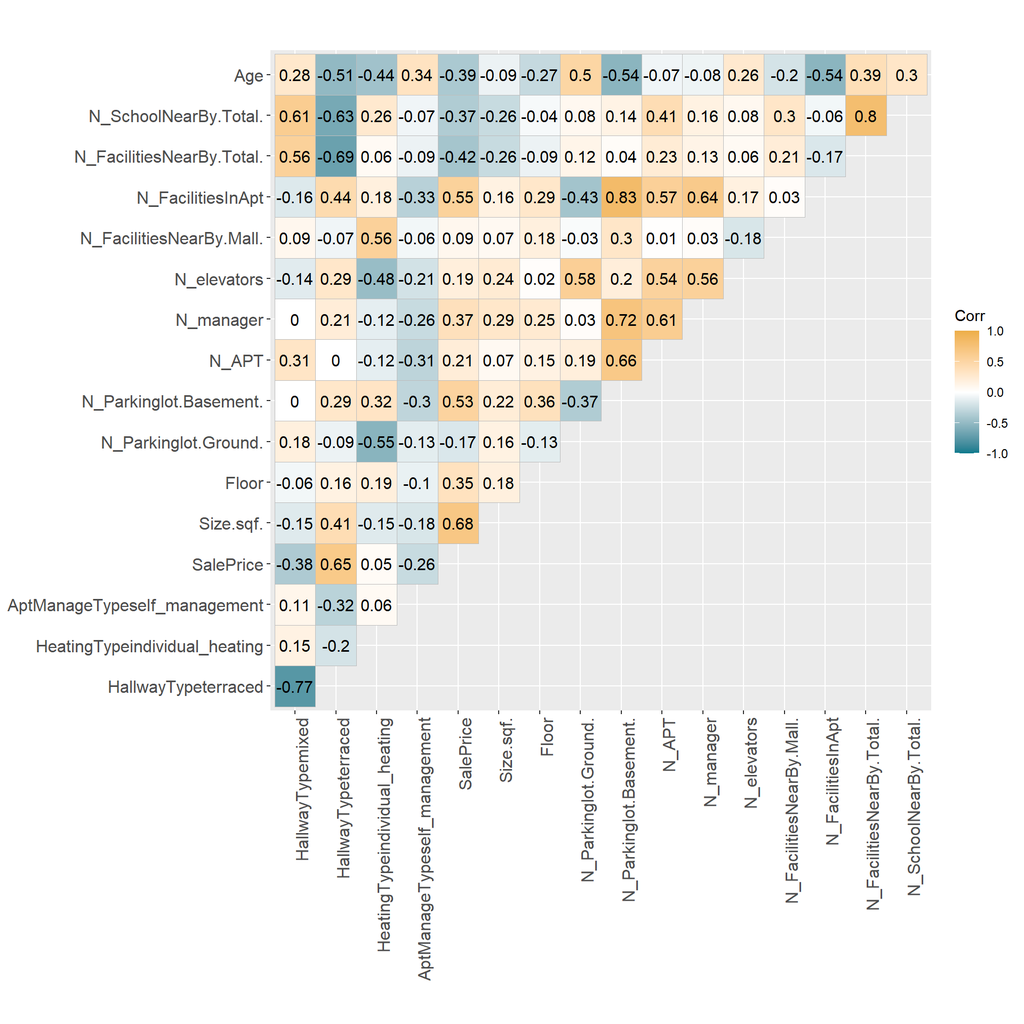

```r
# Plotting the Correlation Heatmap
library(ggcorrplot)
ggcorrplot(cor(dummy_df2_norm), hc.order = F,type =
"upper", lab = T ,
  ggtheme = ggplot2::theme_gray,
  colors = c("#00798c", "white", "#edae49"),
  tl.srt = 90)
```

##**Creating train test sets**##

```r
library(caret)
set.seed(387)
train_data = createDataPartition(y = dummy_df2_norm$SalePrice, p = 0.70, list = FALSE)
test_data =createDataPartition(y=dummy_df2_norm$SalePrice, p=0.30,list=FALSE)
train = dummy_df2_norm[train_data, ]
test = dummy_df2_norm[test_data, ]
```

##**Feature Selection**##

Boruta

```r
library(Boruta)
# Perform Boruta search
boruta_output <- Boruta(SalePrice ~ ., data=na.omit(train), doTrace=0)

names(boruta_output)
```

```
##  [1] "finalDecision" "ImpHistory"    "pValue"        "maxRuns"
##  [5] "light"         "mcAdj"         "timeTaken"     "roughfixed"
##  [9] "call"          "impSource"
```

```r
#install.packages("Boruta")
library(Boruta)


# Do a tentative rough fix
roughFixMod <- TentativeRoughFix(boruta_output)
boruta_signif <- getSelectedAttributes(roughFixMod)
print(boruta_signif)
```

```
##  [1] "HallwayTypemixed"              "HallwayTypeterraced"
##  [3] "HeatingTypeindividual_heating" "AptManageTypeself_management"
##  [5] "Size.sqf."                     "Floor"
##  [7] "N_Parkinglot.Ground."          "N_Parkinglot.Basement."
##  [9] "N_APT"                         "N_manager"
## [11] "N_elevators"                   "N_FacilitiesNearBy.Mall."
## [13] "N_FacilitiesInApt"             "N_FacilitiesNearBy.Total."
## [15] "N_SchoolNearBy.Total."         "Age"
```

```r
# Variable Importance Scores
imps <- attStats(roughFixMod)
imps2 = imps[imps$decision != 'Rejected', c('meanImp', 'decision')]
head(imps2[order(-imps2$meanImp), ])  # descending sort
```

```
##                         meanImp  decision
## Size.sqf.              44.66367 Confirmed
## Age                    34.35337 Confirmed
## N_Parkinglot.Ground.   22.50834 Confirmed
## N_Parkinglot.Basement. 21.57021 Confirmed
## N_manager              20.93525 Confirmed
## N_APT                  20.50568 Confirmed
```

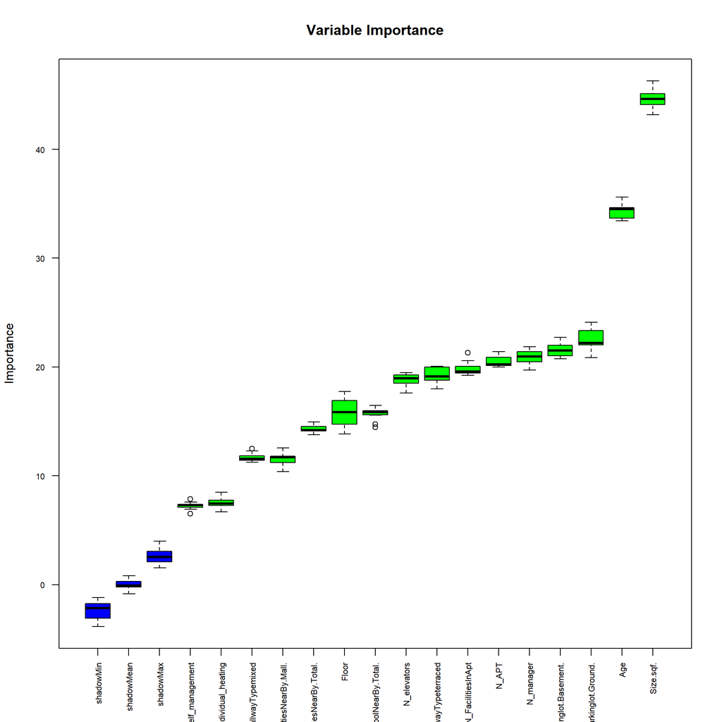

```r
# Plot variable importance
plot(boruta_output, cex.axis=.7, las=2, xlab="", main="Variable Importance")
```

We can see the Size in Sqft is the most imporntant variable

##**Moodel building**##

##**linear regression**##

```r
model = lm( SalePrice ~., data = train)
```

summary of the model

```r
summary(model) # Obtain coefficients, Residuals and statistics
```

```
##
## Call:
## lm(formula = SalePrice ~ ., data = train)
##
## Residuals:
##      Min       1Q   Median       3Q      Max
## -0.63694 -0.05954 -0.00650  0.06050  0.33671
##
## Coefficients:
##                                Estimate Std. Error t value Pr(>|t|)
## (Intercept)                   -0.279067   0.025315 -11.024  < 2e-16 ***
## HallwayTypemixed              -0.014703   0.006898  -2.131   0.0331 *
## HallwayTypeterraced            0.199611   0.012301  16.228  < 2e-16 ***
## HeatingTypeindividual_heating  0.222394   0.017991  12.361  < 2e-16 ***
## AptManageTypeself_management  -0.026996   0.008388  -3.218   0.0013 **
## Size.sqf.                      0.507389   0.010702  47.412  < 2e-16 ***
## Floor                          0.118315   0.008703  13.595  < 2e-16 ***
## N_Parkinglot.Ground.          -0.012505   0.013245  -0.944   0.3452
## N_Parkinglot.Basement.         0.170001   0.023178   7.335 2.70e-13 ***
## N_APT                          0.170740   0.026065   6.550 6.50e-11 ***
## N_manager                     -0.091720   0.016849  -5.444 5.55e-08 ***
## N_elevators                   -0.102714   0.014253  -7.206 6.90e-13 ***
## N_FacilitiesNearBy.Mall.      -0.070588   0.012798  -5.516 3.71e-08 ***
## N_FacilitiesInApt              0.062494   0.015582   4.011 6.17e-05 ***
## N_FacilitiesNearBy.Total.      0.084120   0.019019   4.423 1.00e-05 ***
## N_SchoolNearBy.Total.         -0.155316   0.015570  -9.975  < 2e-16 ***
## Age                            0.289177   0.013884  20.828  < 2e-16 ***
## ---
## Signif. codes:  0 '***' 0.001 '**' 0.01 '*' 0.05 '.' 0.1 ' ' 1
##
## Residual standard error: 0.08897 on 3802 degrees of freedom
## Multiple R-squared:  0.7883, Adjusted R-squared:  0.7874
## F-statistic: 884.8 on 16 and 3802 DF,  p-value: < 2.2e-16
```

```r
rsquare = summary(model)$r.squared # R-squared value
```

Our model performs at 78.8%

##**Predictions**##

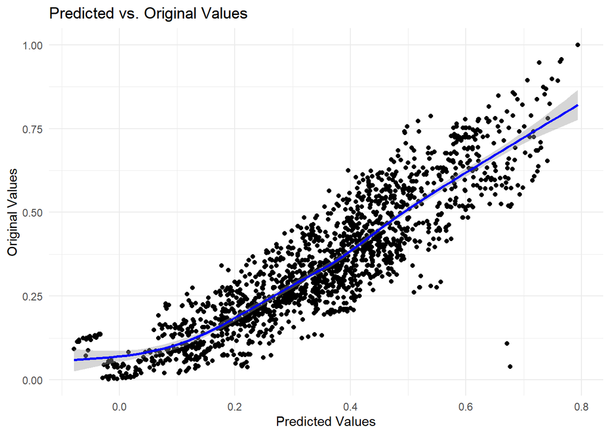

```r
library(ggplot2)
predictions = predict(model, newdata = test)
predicted.vs.original = data.frame(predicted = predictions, original = test$SalePrice)   # Create a new data frame
ggplot(predicted.vs.original, aes(x = predicted, y = original)) +
 geom_point() +
 geom_smooth(color='blue') +
 labs(x = 'Predicted Values', y = 'Original Values', title = 'Predicted vs. Original Values') +
 theme_minimal()
```

The predicted values align themselves on the line of best fit hence meaning that Model works well

##**XGBoost Model**##

```r
library(xgboost)
bstSparse <- xgboost(data=as.matrix(train), label = train$SalePrice, max.depth = 2, eta = 1, nthread = 2, nrounds = 2, objective = "reg:squarederror")
pred <- predict(bstSparse, newdata=as.matrix(test))

# size of the prediction vector
print(length(pred))
```

```
## [1] 1639
```

```r
## [1] 1611

# limit display of predictions to the first few
print(head(pred))
```

```
## [1] 0.10625817 0.04480752 0.28334054 0.28334054 0.10625817 0.04480752
```

```r
 poly_reg = lm(formula = SalePrice ~ .,data = train)
```

```r
#summary(poly_reg)
summary(poly_reg)$r.squared
```

```
## [1] 0.7883006
```

Our Model has an Accuracy of 78%

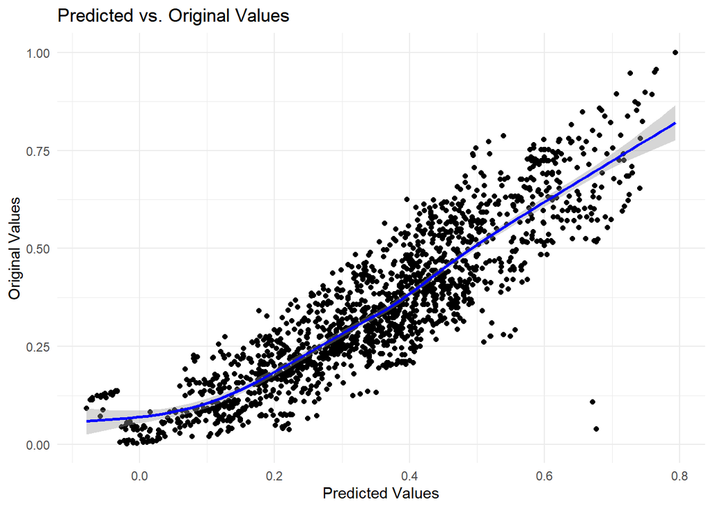

```r
predict = predict(poly_reg, newdata = test)
predicted.vs.original = data.frame(predicted = predict, original = test$SalePrice)   # Create a new data frame
ggplot(predicted.vs.original, aes(x = predicted, y = original)) +
 geom_point() +
 geom_smooth(color='blue') +
 labs(x = 'Predicted Values', y = 'Original Values', title = 'Predicted vs. Original Values') +
 theme_minimal()
```

##**K-MEANS CLUSTERING**##

```r
outputk <- kmeans(dummy_df2_norm, 4)
```

```r
outputk$size
```

```
## [1]  898 2339 1043 1174
```

```r
outputk$centers
```

```
##   HallwayTypemixed HallwayTypeterraced HeatingTypeindividual_heating
## 1        1.0000000           0.0000000                     1.0000000
## 2        0.0000000           0.8952544                     0.8730227
## 3        0.6366251           0.0000000                     1.0000000
## 4        0.0000000           1.0000000                     1.0000000
##   AptManageTypeself_management SalePrice Size.sqf.     Floor
## 1                   0.18151448 0.2358024 0.2956580 0.2483031
## 2                   0.07823856 0.3886860 0.4257892 0.2466052
## 3                   0.00000000 0.1777561 0.3176081 0.2208830
## 4                   0.00000000 0.5089396 0.4088571 0.3545875
##   N_Parkinglot.Ground. N_Parkinglot.Basement.     N_APT N_manager N_elevators
## 1           0.11575669              0.4333602 0.4329993 0.3172863  0.07275427
## 2           0.35595401              0.2484712 0.2357845 0.2809879  0.37303058
## 3           0.55855170              0.2593186 0.4196229 0.4318903  0.58428323
## 4           0.04658317              0.8951874 0.5885860 0.7284760  0.62862010
##   N_FacilitiesNearBy.Mall. N_FacilitiesInApt N_FacilitiesNearBy.Total.
## 1                0.5000000         0.5575353                 0.7671214
## 2                0.4292433         0.4324260                 0.4424701
## 3                0.5000000         0.2929583                 0.8973514
## 4                0.5000000         0.9067765                 0.5991802
##   N_SchoolNearBy.Total.       Age
## 1             0.8114110 0.2714008
## 2             0.4114881 0.2292564
## 3             0.9826293 0.5022248
## 4             0.6453552 0.1045298
```

##**Determining Number of clusters using Elbow Mmethod**##

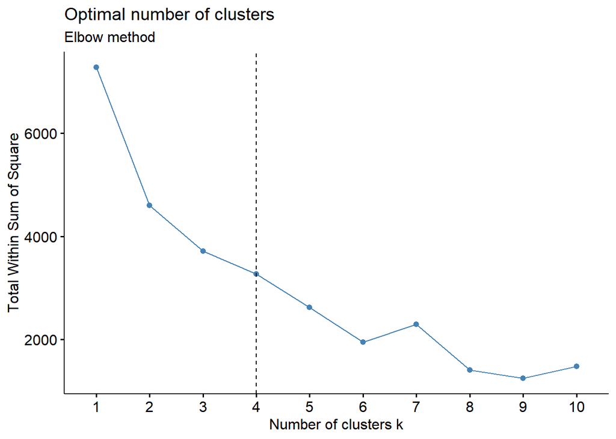

```r
library(factoextra)
# Elbow method
fviz_nbclust(dummy_df2_norm, kmeans, method = "wss") +
    geom_vline(xintercept = 4, linetype = 2)+
  labs(subtitle = "Elbow method")
```

##**Visualising the clusters**##

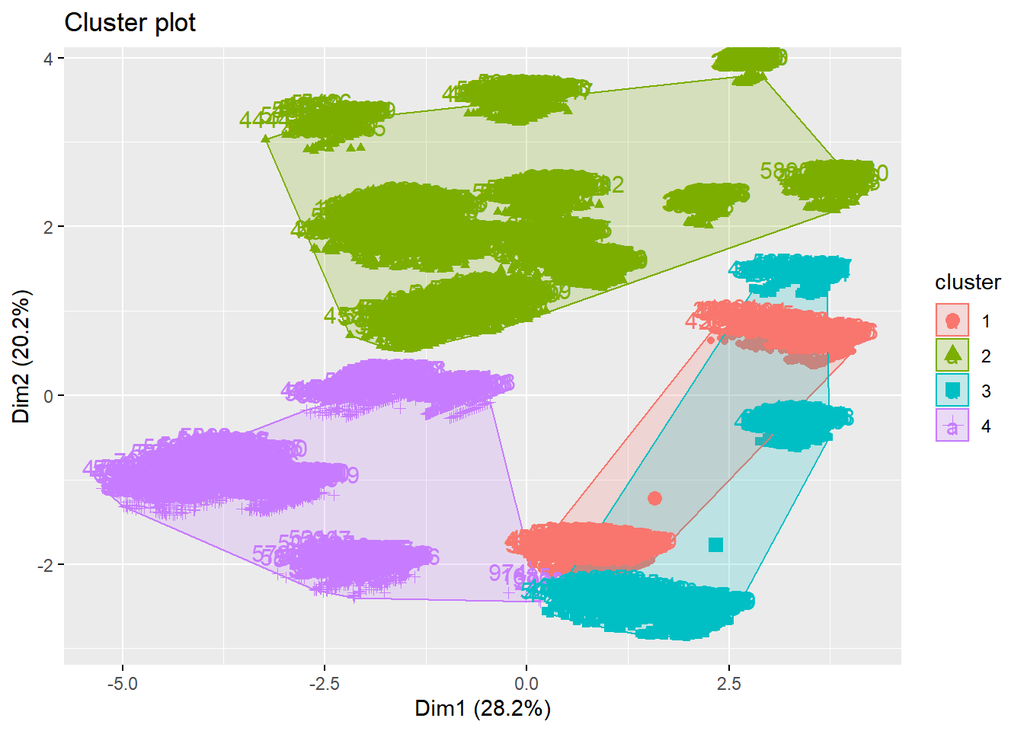

```r
library(factoextra)
options(repr.plot.width = 11, repr.plot.height = 10)
fviz_cluster(outputk, dummy_df2_norm)
```

##**HIERACHICAL CLUSTERING**##

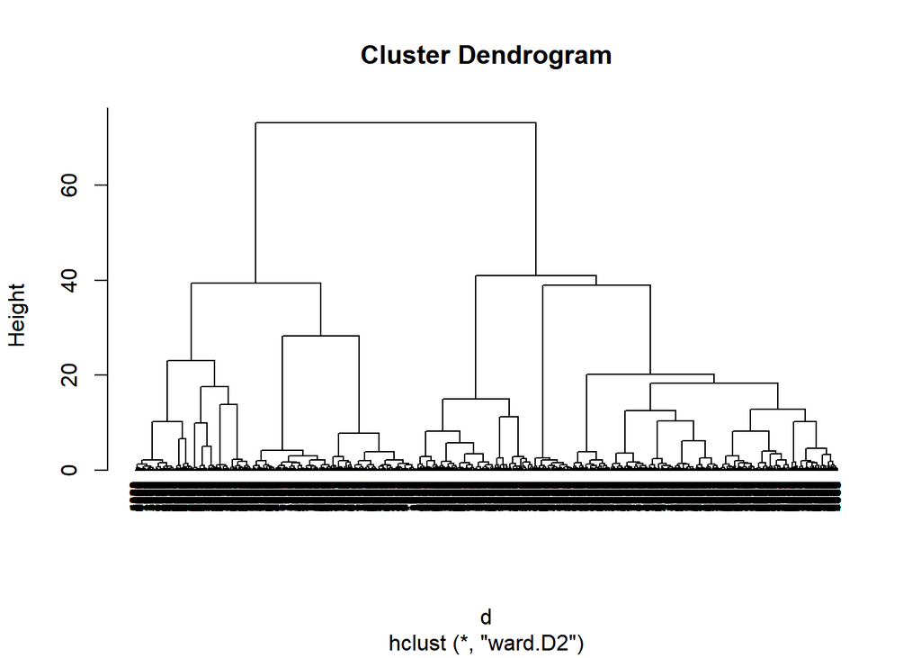

```r
d <- dist(dummy_df2_norm, method = "euclidean")
# We then apply hierarchical clustering using the Ward's method
res.hc <- hclust(d, method = "ward.D2")
# Lastly we plot the obtained dendrogram
#--
plot(res.hc, cex = 0.6, hang = -1)
```

##**Conclusion**##

Our Models have an accuracy of 78%

We can see most apartments have terraced Hallway types.

Most Apartments had Individual Heating System while very few had central heating systems

The data was skewed to the right showing that most apartments were newly built.

The data is skewed to the right suggesting that there are fewer buildings located higher up than those in the lower floors

It is highly likely that the houses located on the higher floors are more expensive than those on the lower floors.

The apartments that were managed by trust were more expensive than those managed by individuals.

Size(sqft) is the most important factor in determining the price of an Apartment

##**Recommendations**##

Renovation of the old Apartments.

We integrate the individual heating system Since most Apartments preferred Individual Heating system.

We recommend Management by Trust since its mostly preferred .

The size of an Apartment really matters as it determines the price of an Apartment.So we recommend bigger appartments